# Creating a Streetmap of Springfield, MO

Connor Rothschild

11/20/2019

In this post, I expand upon the wonderful [Christian Burkhart’s](https://christianburkhart.de/) wonderful [ggplot2tor tutorial](https://ggplot2tutor.com/streetmaps/streetmaps/) on streetmap creation using ggplot2. My process differs slightly from his in that I include text using `geom_label`, rather than PowerPoint, to create the text annotations. (This was much more difficult!)

```r
library(tidyverse)
library(gridExtra)
library(grid)
library(ggplot2)
library(lattice)
library(osmdata)
library(sf)
```

First, per the tutorial, we load street (and river, etc). data:

```r
streets <- getbb("Springfield Missouri")%>%
  opq()%>%
  add_osm_feature(key = "highway",
                  value = c("motorway", "primary",
                            "secondary", "tertiary")) %>%
  osmdata_sf()

small_streets <- getbb("Springfield Missouri")%>%
  opq()%>%
  add_osm_feature(key = "highway",
                  value = c("residential", "living_street",
                            "unclassified",
                            "service", "footway")) %>%
  osmdata_sf()

river <- getbb("Springfield Missouri")%>%
  opq()%>%
  add_osm_feature(key = "waterway", value = "river") %>%
  osmdata_sf()
```

Next, we define the plot limits, using the lat-long found in the last step.

```r
left <- -93.175
right <- -93.395
bottom <- 37
top <- 37.275
```

In my plot, I’m going to create a text box to hold the city, state, and lat/long combination.

We can create the parameters for this box through some manipulations of the existing plot limits:

```r
top_rect = (top + bottom)/2.0035
bot_rect = bottom + .01
box_height = (top_rect + bot_rect)/2
mid_box = (left + right)/2
```

Finally, we can create a black and white plot. This follows the same structure as the ggplot2tor tutorial:

```r
plot_bw <- ggplot() +
  geom_sf(data = streets$osm_lines,
          inherit.aes = FALSE,
          color = "#000000",
          size = .3,
          alpha = .8) +
  geom_sf(data = small_streets$osm_lines,
          inherit.aes = FALSE,
          color = "#000000",
          size = .1,
          alpha = .6) +
  geom_sf(data = river$osm_lines,
          inherit.aes = FALSE,
          color = "#000000",
          size = .2,
          alpha = .5) +
  coord_sf(xlim = c(left, right),
           ylim = c(bottom, top),
           expand = FALSE) +
  theme_void() +
  theme(
    plot.background = element_rect(fill = "#FFFFFF"),
    panel.background = element_rect(fill = "#FFFFFF"),
    plot.margin=unit(c(0,-0.5,0,0), "mm")
  )
```

Finally, we can introduce our text elements using `geom_text` (as well as borders using `geom_rect`).

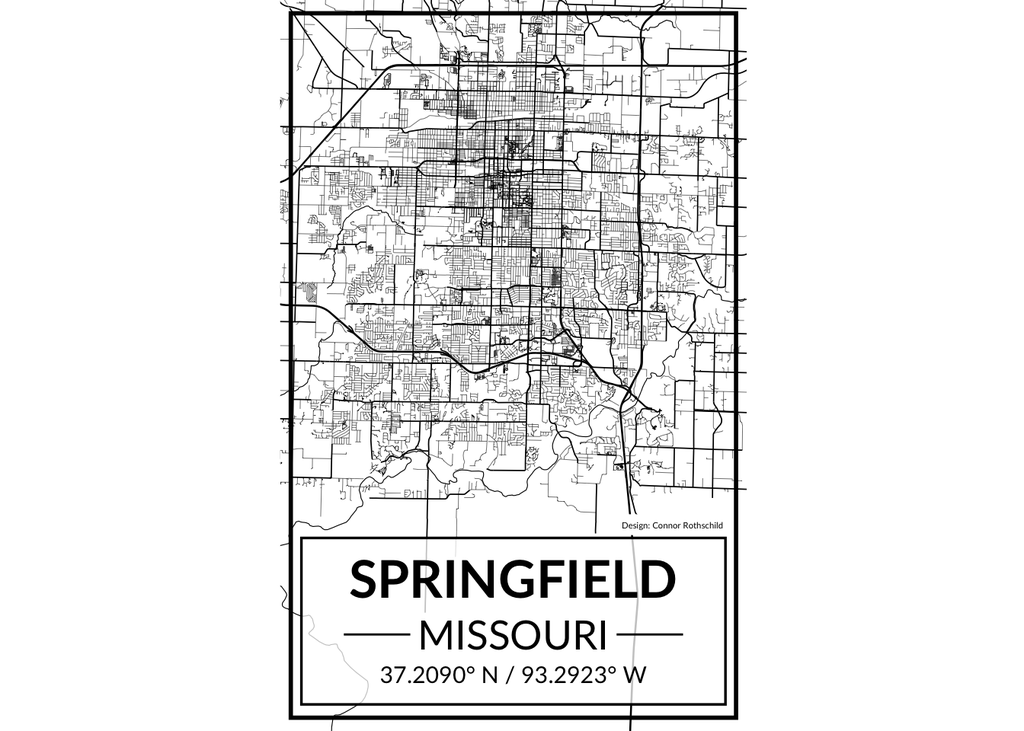

```r
map_bw <- plot_bw +
  geom_rect(aes(xmax = right+.005, xmin = left-.005, ymin = bottom+.005, ymax = top-.005),
            alpha = 0,
            color = "black",
            size = 1) +
  geom_rect(aes(xmax = right+.01, xmin = left-.01, ymin = bot_rect, ymax = top_rect),
            alpha = .75,
            color = "black",
            fill = "white",
            size = .6) +
  geom_text(aes(x = mid_box, y = box_height+.002,
                  label = "SPRINGFIELD\n"),
            color = "black",
            family = "Lato",
            fontface = "bold",
            size = 9) +
  geom_segment(aes(x = left-.03, y = (top_rect + bottom)/2, xend = right+.03, yend = (top_rect + bottom)/2), color = "black") +
  geom_label(aes(x = mid_box, y = box_height-.005,
                  label = "MISSOURI"),
            color = "black",
            fill = "white",
            # alpha = .9,
            label.size = 0,
            family = "Lato",
            # fontface = "thin",
            size = 7) +
  geom_text(aes(x = mid_box, y = box_height-.02,
                label = "37.2090° N / 93.2923° W"),
          color = "black",
          family = "Lato",
          size = 4) +
  geom_label(aes(x = left-.035, y = top_rect + .005, label = "Design: Connor Rothschild"),
          size = 1.5,
          color = "black",
          fill = "white",
          label.size = 0,
          family = "Lato")

map_bw
```

Finally, save the plot:

```r
ggsave(map_bw, filename = "bw_springfield_map.png", width = 3.234, height = 5.016)
```

Replicate that code with different colors:

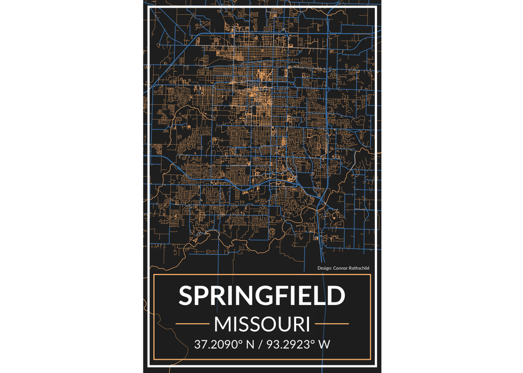

```r
plot_gold <- ggplot() +
  geom_sf(data = streets$osm_lines,
          inherit.aes = FALSE,
          color = "steelblue",
          size = .3,
          alpha = .8) +
    geom_sf(data = small_streets$osm_lines,
          inherit.aes = FALSE,
          color = "#ffbe7f",
          size = .1,
          alpha = .6) +
  geom_sf(data = river$osm_lines,
          inherit.aes = FALSE,
          color = "#ffbe7f",
          size = .2,
          alpha = .5) +
  coord_sf(xlim = c(left, right),
           ylim = c(bottom, top),
           expand = FALSE) +
  theme_void() +
  theme(
    plot.background = element_rect(fill = "#282828"),
    panel.background = element_rect(fill = "#282828"),
    plot.margin=unit(c(0,-0.5,0,0), "mm")
  )

map_gold <- plot_gold +
  geom_rect(aes(xmax = right+.005, xmin = left-.005, ymin = bottom+.005, ymax = top-.005),
            alpha = 0,
            color = "white",
            size = 1) +
  geom_rect(aes(xmax = right+.01, xmin = left-.01, ymin = bot_rect, ymax = top_rect),
            alpha = .5,
            color = "#ffbe7f",
            fill = "#282828",
            size = .5) +
  geom_text(aes(x = mid_box, y = box_height+.002,
                  label = "SPRINGFIELD\n"),
            color = "white",
            family = "Lato",
            fontface = "bold",
            size = 9) +
  geom_segment(aes(x = left-.03, y = (top_rect + bottom)/2, xend = right+.03, yend = (top_rect + bottom)/2),
               color = "#ffbe7f") +
  geom_label(aes(x = mid_box, y = box_height-.005,
                  label = "MISSOURI"),
            color = "white",
            fill = "#282828",
            # alpha = .9,
            label.size = 0,
            family = "Lato",
            # fontface = "thin",
            size = 7) +
  geom_text(aes(x = mid_box, y = box_height-.02,
                label = "37.2090° N / 93.2923° W"),
          color = "white",
          family = "Lato",
          size = 4) +
  geom_label(aes(x = left-.035, y = top_rect + .005, label = "Design: Connor Rothschild"),
            size = 1.5,
            color = "white",
            fill = "#282828",
            label.size = 0,
            family = "Lato")

map_gold
```

```r
ggsave(map_gold, filename = "gold_springfield_map.png", width = 3.234, height = 5.016)
```